# Demande d’électricité en Suisse

Pierrick Vernet

2026-04-16

```r
# importer la base de données
tab<-read.csv("monthly_full_release_long_format(1).csv",na.strings = "", stringsAsFactors = FALSE,  encoding = "UTF-8")

# 1. Définition du pays cible
nom_pays <- "Switzerland"

# 2. Filtrage des données globales pour le pays choisi
df_temp <- subset(tab, Area == nom_pays)

# 3. On créer un dataframe et une time serie
demande <- subset(df_temp, Variable == "Demand", select = Value)
demandets <- ts(demande$Value, frequency = 12, start = c(2017, 1), end = c(2025, 10))

demandedf <- subset(df_temp, Variable == "Demand", select = c(Date, Value))

# 4. Conversion de la colonne Date en format Date R
demandedf$Date <- as.Date(demandedf$Date)

# 5. Vérification de l'intégrité des données
#print(paste("Nombre d'observations :", nrow(demandedf)))
#sum(is.na(demandedf$Value))

rm(tab,df_temp,demande)
```

```r
# on différencie la demande à l'odrdre 12 pour la désaisonnaliser.
d12 = diff(demandets, 12)
```

# 1 **PARTIE 2: MODÉLISATION**

Pour rappel, notre série désaisonnalisée (différenciée à l’ordre 12) `d12` est stationnaire.

# 2 ACF & PACF : Identification de D.

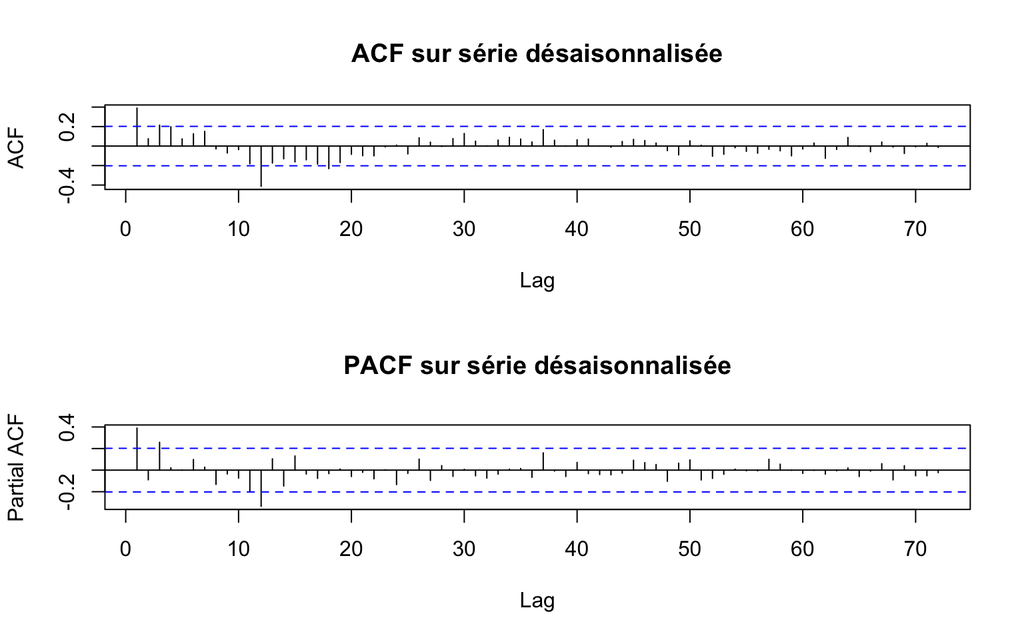

```r
op <- par(mfcol = c(2,1))
acf(as.numeric(d12),  lag.max = 12*6, main = "ACF sur série désaisonnalisée")
pacf(as.numeric(d12), lag.max = 12*6, main = "PACF sur série désaisonnalisée")
```

```r
par(op)
```

On constate que les coefficients multiples de 12 chutent rapidement vers 0, on a donc rho(24) rho(36), … qui ne sont pas significatifs, on pourra donc prendre D = 0 dans la partie saisonnière de notre modèle.

# 3 EACF : Identification des modèles.

```r
eacf(d12)
```

```
## AR/MA
##   0 1 2 3 4 5 6 7 8 9 10 11 12 13
## 0 x o x o o o o o o o o  x  o  o
## 1 x o o o o o o o o o o  x  o  o
## 2 x x x o o o o o o o o  x  o  o
## 3 o o x o o o o o o o o  x  o  o
## 4 x o x o o o o o o o o  x  o  o
## 5 o o o o o o o o o o o  x  o  o
## 6 x x o o x o o o o o o  x  o  o
## 7 o x o x o o o o o o o  x  o  x
```

On repère le coin supérieur gauche du triangle de ‘o’ :

- En (AR=0, MA=3) : le triangle de ‘o’ est propre vers le bas et vers la droite, ce qui suggère un MA(3) sur d12, soit un SARIMA(0,0,3)(0,0,1)[12] sur la série originale.
- En (AR=1, MA=3) : la ligne AR=1 est presque entièrement composée de ‘o’ à partir de MA=2, le triangle de ‘o’ est cohérent, ce qui suggère un ARMA(1,3) sur d12, soit un SARIMA(1,0,3)(0,0,1)[12] sur la série originale.
- En (AR=2, MA=3) : le triangle de ‘o’ est également cohérent, ce qui suggère un ARMA(2,3) sur d12, soit un SARIMA(2,0,3)(0,0,1)[12] sur la série originale.

# 4 Estimation des modèles

## 4.1 Modèle 1 : SARIMA(0,0,3)(0,0,1)[12]

```r
mod1 <- Arima(demandets, order = c(0,0,3), seasonal = list(order = c(0,0,1), period = 12))
coeftest(mod1)
```

```
##
## z test of coefficients:
##
##           Estimate Std. Error z value  Pr(>|z|)
## ma1       0.586354   0.097556  6.0105 1.850e-09 ***
## ma2       0.501354   0.098239  5.1034 3.336e-07 ***
## ma3       0.291640   0.120583  2.4186   0.01558 *
## sma1      0.569091   0.082674  6.8836 5.836e-12 ***
## intercept 5.699100   0.095561 59.6382 < 2.2e-16 ***
## ---
## Signif. codes:  0 '***' 0.001 '**' 0.01 '*' 0.05 '.' 0.1 ' ' 1
```

Tous les coefficients sont significatifs, on garde le modèle 1 comme ça.

Le modèle 1 est donc un SARIMA(0,0,3)(0,0,1)[12] sur la série brute (non désaisonnalisée).

## 4.2 Modèle 2 : SARIMA(1,0,3)(0,0,1)[12]

```r
mod2 <- Arima(demandets, order = c(1,0,3), seasonal = list(order = c(0,0,1), period = 12),fixed = c(NA, NA, NA, NA ,NA,NA))

coeftest(mod2)
```

```
##
## z test of coefficients:
##
##           Estimate Std. Error z value  Pr(>|z|)
## ar1       0.234471   0.238055  0.9849  0.324653
## ma1       0.387839   0.225675  1.7186  0.085693 .
## ma2       0.415097   0.145621  2.8505  0.004365 **
## ma3       0.220081   0.151973  1.4482  0.147573
## sma1      0.561093   0.082921  6.7666 1.319e-11 ***
## intercept 5.701532   0.105117 54.2397 < 2.2e-16 ***
## ---
## Signif. codes:  0 '***' 0.001 '**' 0.01 '*' 0.05 '.' 0.1 ' ' 1
```

Le coefficient phi1 (associé à AR(1)) est le moins significatif : on le retire.

```r
mod2 <- Arima(demandets, order = c(1,0,3), seasonal = list(order = c(0,0,1), period = 12),fixed = c(0, NA, NA, NA ,NA,NA))

coeftest(mod2)
```

```
##
## z test of coefficients:
##
##           Estimate Std. Error z value  Pr(>|z|)
## ma1       0.586351   0.097557  6.0103 1.851e-09 ***
## ma2       0.501348   0.098240  5.1033 3.338e-07 ***
## ma3       0.291623   0.120588  2.4184   0.01559 *
## sma1      0.569106   0.082673  6.8838 5.828e-12 ***
## intercept 5.699104   0.095561 59.6384 < 2.2e-16 ***
## ---
## Signif. codes:  0 '***' 0.001 '**' 0.01 '*' 0.05 '.' 0.1 ' ' 1
```

Tous les coefficients sont significatifs, on garde le modèle 2 comme ceci.

Le modèle 2 est un ARMA(0,0,3) sur `d12`, donc un SARIMA(0,0,3)(0,0,1)[12] sur la série brute.

## 4.3 Modèle 3 : SARIMA(2,0,3)(0,0,1)[12]

```r
mod2 <- Arima(demandets, order = c(2,0,3), seasonal = list(order = c(0,0,1), period = 12))
coeftest(mod2)
```

```
##
## z test of coefficients:
##
##             Estimate Std. Error   z value  Pr(>|z|)
## ar1        1.7309919  0.0044981  384.8249 < 2.2e-16 ***
## ar2       -0.9983590  0.0026217 -380.8072 < 2.2e-16 ***
## ma1       -1.5195255  0.1076087  -14.1208 < 2.2e-16 ***
## ma2        0.6924579  0.1694800    4.0858 4.393e-05 ***
## ma3        0.1807627  0.0953455    1.8959   0.05798 .
## sma1       0.4556795  0.0803432    5.6717 1.414e-08 ***
## intercept  5.6912158  0.0402138  141.5238 < 2.2e-16 ***
## ---
## Signif. codes:  0 '***' 0.001 '**' 0.01 '*' 0.05 '.' 0.1 ' ' 1
```

Le coefficient associé à MA(3) (teta3) n’est pas significatif, on le retire.

```r
mod3 <- Arima(demandets, order = c(2,0,3), seasonal = list(order = c(0,0,1), period = 12), fixed = c(NA,NA,NA,NA,0,NA,NA))
coeftest(mod3)
```

```
##
## z test of coefficients:
##
##             Estimate Std. Error   z value  Pr(>|z|)
## ar1        1.7310939  0.0038058  454.8614 < 2.2e-16 ***
## ar2       -0.9984890  0.0021108 -473.0467 < 2.2e-16 ***
## ma1       -1.6965621  0.0675871  -25.1019 < 2.2e-16 ***
## ma2        0.9998175  0.0769469   12.9936 < 2.2e-16 ***
## sma1       0.4364914  0.0818641    5.3319 9.719e-08 ***
## intercept  5.6898961  0.0345761  164.5616 < 2.2e-16 ***
## ---
## Signif. codes:  0 '***' 0.001 '**' 0.01 '*' 0.05 '.' 0.1 ' ' 1
```

Tous les coefficients du modèle sont maintenant significatifs.

Le modèle 3 est un ARMA(2,0,2) sur `d12`, donc un SARIMA(2,0,2)(0,0,1)[12] sur la série brute.

## 4.4 Modèle 4 : SARIMA(12,0,0)(0,0,1)[12]

```r
# AR12
mod4 <- Arima(demandets, order = c(12,0,0), seasonal = list(order = c(0,0,1), period = 12), method = "ML",
              fixed = c(NA, NA, NA, NA, NA, NA, NA, NA, NA, NA, NA, NA, NA, NA))
coeftest(mod4)
```

```
##
## z test of coefficients:
##
##             Estimate Std. Error  z value  Pr(>|z|)
## ar1        0.0771874  0.0456072   1.6924   0.09056 .
## ar2        0.0381766  0.0441521   0.8647   0.38722
## ar3       -0.0687055  0.0432978  -1.5868   0.11256
## ar4       -0.0356232  0.0448170  -0.7949   0.42670
## ar5       -0.0041485  0.0448446  -0.0925   0.92629
## ar6        0.0067025  0.0384798   0.1742   0.86172
## ar7       -0.0048931  0.0465056  -0.1052   0.91621
## ar8       -0.0613816  0.0460871  -1.3319   0.18291
## ar9       -0.0036970  0.0469550  -0.0787   0.93724
## ar10       0.0449863  0.0485227   0.9271   0.35387
## ar11      -0.0604305  0.0461104  -1.3106   0.19001
## ar12       0.8913005  0.0557461  15.9886 < 2.2e-16 ***
## sma1      -0.5811507  0.1247789  -4.6574 3.202e-06 ***
## intercept  5.6956387  0.0321329 177.2527 < 2.2e-16 ***
## ---
## Signif. codes:  0 '***' 0.001 '**' 0.01 '*' 0.05 '.' 0.1 ' ' 1
```

On retire les coefficients non significatifs grâce à une backward selection (retirer les coefficients les moins significatifs, un par un).

Cela nous donne le modèle 4 suivant (qui est un AR(12) sur notre série `d12`, donc un SARIMA(12,0,0)(0,0,1)[12] sur la série brute) :

```r
mod4 <- Arima(demandets, order = c(12,0,0), seasonal = list(order = c(0,0,1), period = 12), method = "ML",
              fixed = c(NA, 0, NA, 0, 0, 0, 0, NA, 0, NA, NA, NA, NA, NA))
coeftest(mod4)
```

```
##
## z test of coefficients:
##
##            Estimate Std. Error  z value  Pr(>|z|)
## ar1        0.107743   0.033157   3.2495  0.001156 **
## ar3       -0.063412   0.022482  -2.8206  0.004793 **
## ar8       -0.060758   0.024939  -2.4363  0.014839 *
## ar10       0.067226   0.022423   2.9981  0.002717 **
## ar11      -0.074662   0.033326  -2.2404  0.025066 *
## ar12       0.904169   0.023671  38.1980 < 2.2e-16 ***
## sma1      -0.564868   0.095243  -5.9308 3.014e-09 ***
## intercept  5.701242   0.042551 133.9875 < 2.2e-16 ***
## ---
## Signif. codes:  0 '***' 0.001 '**' 0.01 '*' 0.05 '.' 0.1 ' ' 1
```

## 4.5 Modèle 5 : SARIMA(0,0,12)(0,0,1)[12]

```r
#MA12

mod5 <- Arima(demandets, order = c(0,0,12), seasonal = list(order = c(0,0,1), period = 12))
coeftest(mod5)
```

```
##
## z test of coefficients:
##
##             Estimate Std. Error  z value  Pr(>|z|)
## ma1        0.4598054  0.1135710   4.0486 5.152e-05 ***
## ma2        0.2812059  0.1439434   1.9536 0.0507502 .
## ma3       -0.0143869  0.1476913  -0.0974 0.9223991
## ma4       -0.1535290  0.1450759  -1.0583 0.2899340
## ma5       -0.2717257  0.1375976  -1.9748 0.0482926 *
## ma6       -0.3741215  0.1433187  -2.6104 0.0090432 **
## ma7       -0.2660229  0.1342443  -1.9816 0.0475204 *
## ma8       -0.4241325  0.1191121  -3.5608 0.0003697 ***
## ma9       -0.3856103  0.1319834  -2.9217 0.0034817 **
## ma10      -0.0472600  0.1592781  -0.2967 0.7666849
## ma11       0.0198460  0.1995308   0.0995 0.9207705
## ma12       0.1761261  0.1360516   1.2946 0.1954741
## sma1       0.4705991  0.1080401   4.3558 1.326e-05 ***
## intercept  5.6776331  0.0094963 597.8797 < 2.2e-16 ***
## ---
## Signif. codes:  0 '***' 0.001 '**' 0.01 '*' 0.05 '.' 0.1 ' ' 1
```

On retire les coefficients non significatifs grâce à une backward selection (retirer les coefficients les moins significatifs, un par un).

Nous obtenons le modèle 5 suivant (un MA(9) sur `d12`, donc un SARIMA(0,0,9)(0,0,1)[12] sur la série brute) :

```r
mod5 <- Arima(demandets, order = c(0,0,12), seasonal = list(order = c(0,0,1), period = 12),
              fixed = c(NA, NA, 0, 0, 0, 0, 0, NA, NA, 0, 0, 0, NA, NA))
coeftest(mod5)
```

```
##
## z test of coefficients:
##
##            Estimate Std. Error  z value  Pr(>|z|)
## ma1        0.542474   0.099909   5.4297 5.645e-08 ***
## ma2        0.317283   0.095215   3.3323 0.0008614 ***
## ma8       -0.359204   0.087726  -4.0946 4.229e-05 ***
## ma9       -0.350619   0.097768  -3.5862 0.0003355 ***
## sma1       0.587774   0.081520   7.2102 5.588e-13 ***
## intercept  5.688157   0.045857 124.0419 < 2.2e-16 ***
## ---
## Signif. codes:  0 '***' 0.001 '**' 0.01 '*' 0.05 '.' 0.1 ' ' 1
```

Pour valider nos modèles, nous analysons les résidus.

Un bon modèle doit présenter des aléas qui sont un bruit blanc et suivant une loi normale pour pouvoir utiliser l’intervalle de confiance des prévisions.

À titre d’exemple, nous présentons ici les résultats détaillés pour le Modèle 4, puis nous analyserons les résultats pour l’ensemble des modèles.

# 5 Tests des résidus des modèles

Nous analysons ici le modèle 4 : SARIMA(12,0,0)(0,0,1)[12]

## 5.1 Test de Jarque-Bera (normalité des Aléas) :

$$\left\{
\begin{aligned}
H_0 &: \text{les aléas suivent une loi normale} \\
H_1 &: \text{les aléas ne suivent pas une loi normale}
\end{aligned}
\right.$$

```r
# Récupération des résidus
res4 <- residuals(mod4)

# 1. Test de Normalité (Jarque-Bera)
# H0 : Les résidus suivent une loi normale
jarque.bera.test(res4)
```

```
##
##  Jarque Bera Test
##
## data:  res4
## X-squared = 0.010281, df = 2, p-value = 0.9949
```

Nous testons la normalité des aléas du modèle 4 afin de nous assurer de la validité des intervalles de prédiction futurs.

La règle de décision stipule que si la p-value est inférieure au seuil de 5%, nous rejetons l’hypothèse nulle de normalité des aléas.

Avec une p-value de 0.9949 pour le test de Jarque-Bera, nous acceptons l’hypothèse H0 et concluons que les aléas suivent une loi normale pour notre modèle 4.

## 5.2 Test de Ljung-Box (autocorrélation des aléas) :

$$\left\{
\begin{aligned}
H_0 &: \text{les aléas sont non autocorrélés} \\
H_1 &: \text{les aléas sont autocorrélés}
\end{aligned}
\right.$$

```r
# 2. Test de Bruit Blanc (Ljung-Box)
# H0 : Absence d'autocorrélation des résidus
# On teste sur 20 retards pour capter d'éventuels restes de saisonnalité
Box.test(res4, lag = 24, type = "Ljung-Box")
```

```
##
##  Box-Ljung test
##
## data:  res4
## X-squared = 28.318, df = 24, p-value = 0.2469
```

Nous vérifions l’indépendance des aléas par le test de Ljung-Box pour garantir qu’aucune autocorrélation n’a été oubliée par le modèle.

La règle de décision consiste à rejeter l’hypothèse nulle d’absence d’autocorrélation si la p-value est inférieure à 5%.

Dans le cas du modèle 4, la p-value s’élève à 0.2469, on accepte donc H0, ainsi les aléas ne sont pas autocorrélés.

## 5.3 T-test (espérance nulle des Aléas) :

$$\left\{
\begin{aligned}
H_0 &: \mathbb{E}({\varepsilon}_t) = 0 \\
H_1 &: \mathbb{E}({\varepsilon}_t) \neq 0
\end{aligned}
\right.$$

```r
# 3. Test d'Espérance Nulle (T-Test)
t.test(res4)
```

```
##
##  One Sample t-test
##
## data:  res4
## t = 0.50087, df = 105, p-value = 0.6175
## alternative hypothesis: true mean is not equal to 0
## 95 percent confidence interval:
##  -0.02609056  0.04372698
## sample estimates:
##  mean of x
## 0.00881821
```

La règle de décision indique que nous rejetons H0 : les aléas ont une espérance nulle, si la p-value est strictement inférieur à 0.05.

Le test affiche ici une p-value de 0.6175, nous acceptons H0 et confirmons donc que les aléas possèdent une espérance nulle.

## 5.4 Test d’Engle (homoscédasticité conditionnelle des Aléas) :

$$\left\{
\begin{aligned}
H_0 &: \text{les aléas sont conditionnellement homoscédastiques} \\
H_1 &: \text{les aléas sont conditionnellement hétéroscédastiques}
\end{aligned}
\right.$$

```r
# 4. Test d'Effet ARCH (Engle-ARCH)
# H0 : Absence d'hétéroscédasticité conditionnelle (variance constante)
ArchTest(res4)
```

```
##
##  ARCH LM-test; Null hypothesis: no ARCH effects
##
## data:  res4
## Chi-squared = 9.4262, df = 12, p-value = 0.6662
```

Enfin, nous examinons l’homoscédasticité conditionnelle des résidus via le test d’Engle pour s’assurer de la stabilité de la variance dans le temps.

Selon la règle de décision, une p-value inférieur au seuil de 5% signifie que nous rejetons l’hypothèse nulle d’aléas sont conditionnellement homoscédastiques.

Avec une p-value de 0.6662, nous acceptons H0 et concluons que les aléas sont conditionnellement homoscédastiques.

## 5.5 Récapitulatif des Tests

```r
# --- Création de la table_tests ---
table_tests <- data.frame(
  Modele = c("mod1", "mod2", "mod3", "mod4", "mod5"),
  Jarque_Bera = sapply(list(mod1, mod2, mod3, mod4, mod5), function(m) round(jarque.bera.test(residuals(m))$p.value, 4)),
  Ljung_Box = sapply(list(mod1, mod2, mod3, mod4, mod5), function(m) round(Box.test(residuals(m), lag = 24, type = "Ljung-Box")$p.value, 4)),
  T_test = sapply(list(mod1, mod2, mod3, mod4, mod5), function(m) round(t.test(residuals(m))$p.value, 4)),
  Engle_ARCH = sapply(list(mod1, mod2, mod3, mod4, mod5), function(m) round(ArchTest(residuals(m))$p.value, 4))
)

# --- Affichage ---
kable(table_tests)
```

| Modele | Jarque_Bera | Ljung_Box | T_test | Engle_ARCH |
| --- | --- | --- | --- | --- |
| mod1 | 0.8562 | 0.0000 | 0.7931 | 0.6500 |
| mod2 | 0.4586 | 0.0000 | 0.9379 | 0.0421 |
| mod3 | 0.7424 | 0.0000 | 0.9027 | 0.0631 |
| mod4 | 0.9949 | 0.2469 | 0.6175 | 0.6662 |
| mod5 | 0.7038 | 0.0000 | 0.8945 | 0.6373 |

Pour le test de Jarque Bera, tous les modèles ont une pvalue supérieur à 5%, ainsi les aléas des 5 modèles suivent une loi normale, on peut donc utiliser l’intervalle de confiance des prédicitons avec chaque modèle.

Pour le test de Ljung-Box, on voit que seul le modèle 4 a des aléas non autocorrelés, les autres modèles sont donc à éliminer.

Pour le T-test, tous les modèles ont une pvalue supérieur à 5% et ont donc des aléas d’espérance nulle.

Enfin pour le test d’Engle, on constate que les modèles: 1,3,4,5 ont des pvalue supérieur à 5 %, leurs aléas sont conditionnellement homoscédastiques. En revanche le modèle 2 une pvalue inférieur à 5 %, ses aléas sont donc conditionnellement hétéroscédastiques, si on utilise le modèle 2, il faudra donc modéliser sa variance avec un modèle ARCH ou GARCH.

Le seul modèle qui valide les tests et peut donc être utilisé, est le modèle 4 : SARIMA(12,0,0)(0,0,1)[12]

# 6 Performances des modèles

```r
# --- Création de la table_performance ---
table_performance <- data.frame(
  Modele = c("mod1", "mod2", "mod3", "mod4", "mod5"),
  AIC = sapply(list(mod1, mod2, mod3, mod4, mod5), function(m) round(AIC(m), 2)),
  BIC = sapply(list(mod1, mod2, mod3, mod4, mod5), function(m) round(BIC(m), 2))
)

# --- Affichage ---
kable(table_performance)
```

| Modele | AIC | BIC |
| --- | --- | --- |
| mod1 | 45.60 | 61.58 |
| mod2 | 9.15 | 30.46 |
| mod3 | 10.46 | 29.11 |
| mod4 | -27.81 | -3.84 |
| mod5 | 35.35 | 54.00 |

Pour conclure sur la sélection du meilleur modèle, nous comparons les critères d’information AIC et BIC. Nous privilégions le modèle ayant les valeurs les plus faibles.

On constate immédiatement que le modèle 4 se détache nettement des autres avec un AIC de -27.81 et un BIC de -3.84, soit les seules valeurs négatives du tableau. En comparaison, les modèles 1, 2, 3 et 5 affichent des scores bien plus élevés, dépassant tous les 9 points pour l’AIC et les 29 points pour le BIC.

Le modèle 4 est donc le plus performant et le plus équilibré. Couplé aux résultats des tests sur les résidus, il s’impose comme le modèle final pour réaliser nos prévisions.

**Nous utiliserons donc le modèle 4 : SARIMA(12,0,0)(0,0,1)[12]**

# 7 Prévision

```r
# h = 12 correspond à 12 mois (1 an) de prévision
# level = 0.95 pour l'intervalle de confiance à 95%
prev_mod4 <- forecast(mod4, h = 12, level = 0.95)

# Affichage des valeurs prévues et des intervalles
print(prev_mod4)
```

```
##          Point Forecast    Lo 95    Hi 95
## Nov 2025       5.950243 5.582061 6.318424
## Dec 2025       6.356979 5.986667 6.727292
## Jan 2026       6.613171 6.242839 6.983504
## Feb 2026       5.927382 5.556343 6.298421
## Mar 2026       5.907714 5.536642 6.278787
## Apr 2026       5.396216 5.025143 5.767289
## May 2026       5.444570 5.073495 5.815646
## Jun 2026       5.428949 5.057873 5.800025
## Jul 2026       5.505199 5.133455 5.876942
## Aug 2026       5.375167 5.003392 5.746943
## Sep 2026       5.333235 4.960690 5.705781
## Oct 2026       5.577070 5.204017 5.950122
```

Les prévisions générées par notre modèle SARIMA(12,0,0)(0,0,1)[12] semblent être cohérentes, on observe bien le pic attendu durant l’hiver et le creux attendu durant l’été.

Grâce à la normalité des aléas, nous pouvons utiliser l’intervalle de confiance des prévisions, et nous pouvons affirmer avec un niveau de confiance de 95 % que la demande réelle se situera à l’intérieur des bornes `Lo 95` et `Hi 95` calculées pour chaque mois.

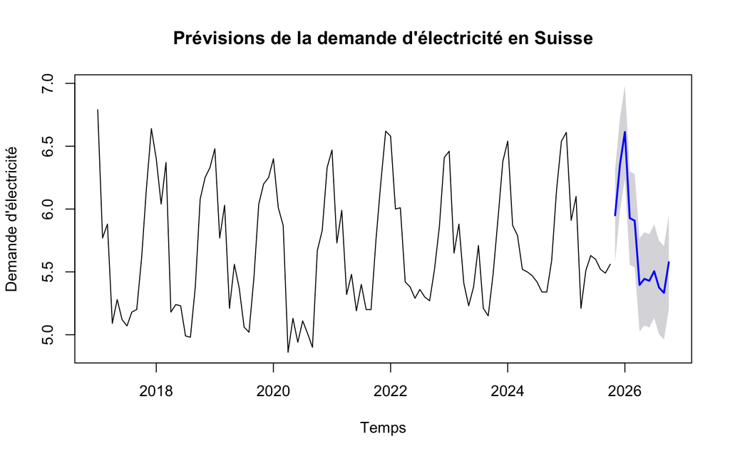

```r
# Tracé du graphique des prévisions
plot(prev_mod4,
     main = "Prévisions de la demande d'électricité en Suisse",
     ylab = "Demande d'électricité",
     xlab = "Temps",
     fcol = "blue",     # Couleur de la ligne de prévision
     flwd = 2)          # Épaisseur de la ligne
```

# 8 Conclusion

Cette étude a permis de modéliser et de prévoir la demande d’électricité en Suisse.

Parmi les modèles estimés, le SARIMA(12,0,0)(0,0,1)[12] (Modèle 4) s’est imposé comme le plus performant grâce à la minimisation des critères AIC et BIC.

Surtout, il est le seul dont les résidus valident l’ensemble des tests post-estimation, formant un bruit blanc gaussien et conditionnellement homoscédastique.

Ces propriétés valident rigoureusement les intervalles de confiance à 95 % des prévisions.

Sur un horizon de 12 mois, le modèle capture fidèlement la dynamique saisonnière et constitue ainsi un outil de prévision fiable pour anticiper les besoins énergétiques.